# P2: Investigate the Baseball Dataset

Step One - Choosing the Data Set In this analysis, Baseball Data have been chosen. The zip was downloaded and extracted. Step Two - Getting Organized A folder baseball was created to extract and save the files and save the iPython Notebook. Step Three - Analyze the Data (1) Baseball Data file Teams.csv will be analysed to find the relationshiop between performance metrics. The positive and negative relationships will be analyzed and the results will be displayed as scatter plots and also in terms of Pearson's Correlation Coefficient. (2) Salaries.csv and AwardsPlayers.csv will be analyzed for the characteristics of the players to find out if they are reflected in there is high salaries. Independent variables like the years of experience and the height of the player and the awards will be analyzed vis-a-vis the salary to find out any relationship. In this case, multiple linear regression analysis is planned Step Four - Sharing the Findings The analysis done in the iPython Notebook will be downloaded as an html file and project submitted. Step Five - Review The Project Rubric will be used to review the project to make sure that the project conforms to the requirements.

# Plan for the analysis:

The main areas of analysis are: What is the relationship between different performance metrics? Do any have a strong negative or positive relationship? What are the characteristics of baseball players with the highest salaries? Here is the overll plan for the analysis: 1) To answer the first question, the relationship between the Wins and Runs (Runs Scored, Runs Allowed and Run Difference) will be analyzed first. Data will be prepared and to find out the pattern, scatter plots will be drawn. Then Pearson's Correlation Coefficient will be calculated and discussed. 2) As a continuation of the first question, the relationship between the Wins and Ranks and the Losses and the Rank of the teams will be plotted as bar diagrams to find out the trend between them. For this the mean of the Wins and Losses will be caculated using the groupby function and the mean values will be used. 3) In the last part, both single-variable (1d) and multiple-variable (2d) explorations will be done as below: a) Histogram will be plotted for the salary ranges of the players and the frequency to find out how the players' salaries are depicted in the histogram b) From the Master file, the no. of players will be plotted as a bar diagram based on the birth country c) For the second question (players' characteristics vs. salaries), for the multiple-variable analysis, first the Salary will be plotted as a scatter diagram against the players' characteristics like the Awards Won, the Years of Experience and the Height. This will be followed by Pearson's Correlation Coefficients for each case and interpretation will be rendered. d) To continue the multiple_variable analysis, a fitted model will be created using Statsmodel's Ordinary Least Squares function and the results will be interpretted. The limitation will be hightlighted during the analysis and a conclution section will be added at the end.

# Part 1: Analysis of relationship between Wins and Runs

In this part, we will look at the data from Teams.csv file and filter the data for the year 2014. This file has columns Wins, Losses, Runs Scored and Runs Allowed. Obviously, in order to win more Games, the teams have to strive for achieving more Runs Scored and contain the Run Allowed. Thus Runs Scored and Runs Allowed will have a relationship with the Wins and Losses. The Run Difference will be another factor that will have a bearing on the No. of Wins and Losses. So a new column will be added RDiff = Runs Scored minus Runs Allowed. And Scatter Plots will be run for the No.Wins Vs. Run Difference,Runs Scored, and Runs Allowed respectively. The Pearson' Correlation Coefficients will be calculated for each scenario and the Significance will be analysed. The following code does the Data Wrangling, Plotting, Calculation and Interpretation

```python
#Change the working directory to the folder containing the project related files
import os
os.chdir('C:/Ramanathan/Data Science Documents/Udacity/P2/Baseball/revised')
os.getcwd()
```

```
'C:\\Ramanathan\\Data Science Documents\\Udacity\\P2\\Baseball\\revised'
```

```python
#Teams.csv file is chosen for analysis of the relationship between Wins and the Runs.
#Read the file using pd.read_csv to create a dataframe and create a new column RDiff with the difference between Runs
#Scored ['R] and Runs Allowed ['RA]
#Print samples rows to look at the data using head() built-in function
import pandas as pd
import csv
baseball = pd.read_csv('Teams.csv')
baseball['RDiff'] = baseball['R'] - baseball['RA']
baseball.head()
```

|  | yearID | lgID | teamID | franchID | divID | Rank | G | Ghome | W | L | ... | FP | name | park | attendance | BPF | PPF | teamIDBR | teamIDlahman45 | teamIDretro | RDiff |
| --- | --- | --- | --- | --- | --- | --- | --- | --- | --- | --- | --- | --- | --- | --- | --- | --- | --- | --- | --- | --- | --- |
| 0 | 1871 | NaN | BS1 | BNA | NaN | 3 | 31 | NaN | 20 | 10 | ... | 0.83 | Boston Red Stockings | South End Grounds I | NaN | 103 | 98 | BOS | BS1 | BS1 | 98 |
| 1 | 1871 | NaN | CH1 | CNA | NaN | 2 | 28 | NaN | 19 | 9 | ... | 0.82 | Chicago White Stockings | Union Base-Ball Grounds | NaN | 104 | 102 | CHI | CH1 | CH1 | 61 |
| 2 | 1871 | NaN | CL1 | CFC | NaN | 8 | 29 | NaN | 10 | 19 | ... | 0.81 | Cleveland Forest Citys | National Association Grounds | NaN | 96 | 100 | CLE | CL1 | CL1 | -92 |
| 3 | 1871 | NaN | FW1 | KEK | NaN | 7 | 19 | NaN | 7 | 12 | ... | 0.80 | Fort Wayne Kekiongas | Hamilton Field | NaN | 101 | 107 | KEK | FW1 | FW1 | -106 |
| 4 | 1871 | NaN | NY2 | NNA | NaN | 5 | 33 | NaN | 16 | 17 | ... | 0.83 | New York Mutuals | Union Grounds (Brooklyn) | NaN | 90 | 88 | NYU | NY2 | NY2 | -11 |

5 rows × 49 columns

```python
#Filter the data using pandas boolean indexing method to filter the data for the Year 2014
baseball_2014 = baseball[baseball['yearID']==2014]
baseball_2014.head()
```

[output not shown]

5 rows × 49 columns

# Pearson's Correlation Coefficient

Correlation is a technique for investigating the relationship between two quantitative, continuous variables, for example, age and blood pressure. Pearson's correlation coefficient (r) is a measure of the strength of the association between the two variables. The first step in studying the relationship between two continuous variables is to draw a scatter plot of the variables to check for linearity. The correlation coefficient should not be calculated if the relationship is not linear. For correlation only purposes, it does not really matter on which axis the variables are plotted. However, conventionally, the independent (or explanatory) variable is plotted on the x-axis (horizontally) and the dependent (or response) variable is plotted on the y-axis (vertically). The nearer the scatter of points is to a straight line, the higher the strength of association between the variables. Also, it does not matter what measurement units are used.

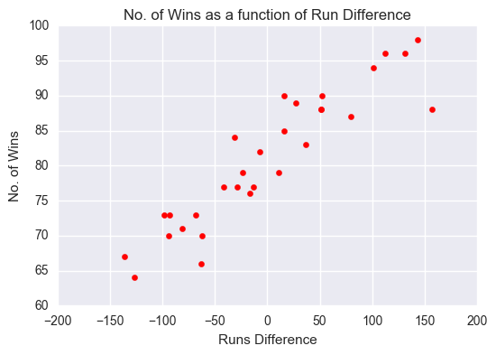

```python
#Plot the dependent variable and the independent variable as a scatter to find out the relationship
#The first plot is No.of Wins (dependent variable) against Runs Difference (independent variable)
import matplotlib
import numpy as np
import matplotlib.pyplot as plt
import seaborn as sbn
%matplotlib inline
x = baseball_2014['RDiff']
y = baseball_2014['W']
plt.scatter(x, y,color='red')
plt.title('No. of Wins as a function of Run Difference')
plt.xlabel('Runs Difference')
plt.ylabel('No. of Wins')
plt.show()
```

# Values of Pearson's correlation coefficient

```python
#To find out the Pearson r value
import scipy.stats
c = scipy.stats.pearsonr(baseball_2014['W'],baseball_2014['RDiff'])
print c
```

```
(0.92062542457550944, 5.9097599778429089e-13)
```

# Significance

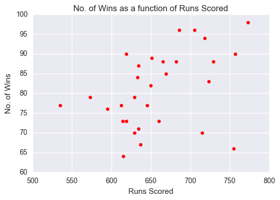

```python
#Plot the dependent variable and the independent variable as a scatter to find out the relationship
#The second plot is No.of Wins (dependent variable) against Runs Scored (independent variable)
x = baseball_2014['R']
y = baseball_2014['W']
plt.scatter(x, y,color='red')
plt.title('No. of Wins as a function of Runs Scored')
plt.xlabel('Runs Scored')
plt.ylabel('No. of Wins')
plt.show()
```

# Values of Pearson's correlation coefficient

Even though we expect a linear relationship between No. of Wins and Run Scored, the data lie scattered without a clear pattern, though there is an increase in the Wins and Runs Scored. We cannot infer a strong linear relationship. Now let us find out the Pearson's correlation coefficient (r) value using scipy.stats

```python
#To find out the Pearson r value
c1 = scipy.stats.pearsonr(baseball_2014['W'],baseball_2014['R'])
print c1
```

```
(0.41046445694977179, 0.024258742839868071)
```

# Significance

We can conclude that there is some relationship between the variables (No. of Wins Vs. Runs Scored) and that the strength of association between the variables is weak to moderate (the range is >0.3 and <0.5) and in this case, it is (r = 0.410).The p-value of 0.024 is greater than 0.01, the data is not significant. So mere increase in Runs Scored is not significant, vis-a-vis the Runs Difference. Let us analysis the Relationship between Wins and Runs Allowed next.

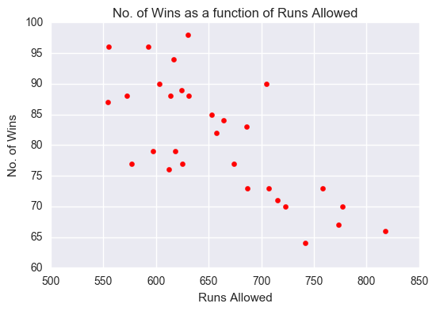

```python
#Plot the dependent variable and the independent variable as a scatter to find out the relationship
#The third plot is No.of Wins (dependent variable) against Runs Allowed (independent variable)
x = baseball_2014['RA']
y = baseball_2014['W']
plt.scatter(x, y,color='red')
plt.title('No. of Wins as a function of Runs Allowed')
plt.xlabel('Runs Allowed')
plt.ylabel('No. of Wins')
plt.show()
```

# Values of Pearson's correlation coefficient

Data lie on a ppatern with a negative slope. Thus there is a negative relationship between the Wins and Runs Allowed. Obviously, if a team allows more run to the opponents, their wins will decline. Now let us find out the Pearson's correlation coefficient (r) value using scipy.stats

```python
c2 = scipy.stats.pearsonr(baseball_2014['W'],baseball_2014['RA'])
print c2
```

```
(-0.72900285572580192, 4.9024286679182995e-06)
```

# Significance

As expected from the Scatter Plot, there is a negative r = -0.73 in this case. The strength of association between the variables(Wins vs. Runs Allowed) is high. The p-value of 0.000 which is less than 0.01, the data is significant. We can also say that [-0.73^2] OR 53% of the decline in the Wins can be explained by the Runs Allowed.

# Part 2: Analysis of relationship between Rank and Wins

In the second part, we will look at the data from Teams.csv file for the year 2014. This file has column Rank for the various teams. We will find out the mean of the Wins grouped by Rank and find out if there is any relationship between the Rank and the mean values of the Wins. The following code does the Data Wrangling, Plotting, Calculation and Interpretation.

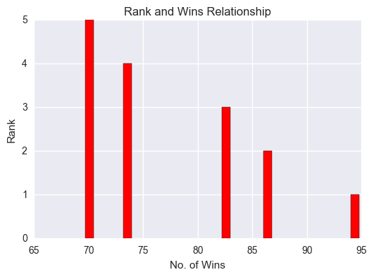

```python
# PLot a Bar Chart with the mean value of No. of Wins for each Rank
import matplotlib
import numpy as np
import matplotlib.pyplot as plt
import seaborn as sbn
%matplotlib inline

x = baseball_2014['W'].groupby(baseball_2014['Rank']).mean()
y = set(baseball_2014['Rank'])
plt.bar(x, y,color='red')
plt.title('Rank and Wins Relationship')
plt.xlabel('No. of Wins')
plt.ylabel('Rank')
plt.show()
```

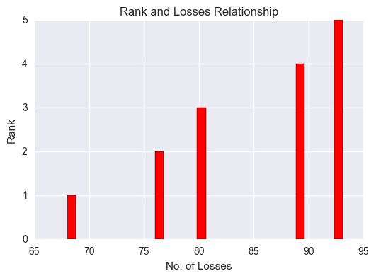

```python
# PLot a Bar Chart with the mean value of No. of Losses for each Rank
x = baseball_2014['L'].groupby(baseball_2014['Rank']).mean()
y = set(baseball_2014['Rank'])
plt.bar(x, y,color='red')
plt.title('Rank and Losses Relationship')
plt.xlabel('No. of Losses')
plt.ylabel('Rank')
plt.show()
```

# Conclusion:

From the above two Bar Charts it can be inferred that the more No. of Wins the better is the Rank achieved by the Teams. Conversely, the more No. of Lost Games, the lower the Rank.

# Part 3: Analysis of players' characteristics and their Salaries

In the third part, we will look at the data from Salries.csv,Master.csv and AwardsPlayers.csv files for the year 2014. These files will be used to extract data of the salaries for the year 2014, the Players' biometric data like height and their experience (the no. of years they have played the game). We will analyze the data for finding out the relationship between: 1) Salary and Awards won by players 2) Salary and Years of Experience in the game 3) Salary and the player's height In the last step, we will run a Multi Linear Regression calculation and print out the results of the fitted model and analyze the results. The following code does the Data Wrangling, Plotting, Calculation and Interpretation.

# Data cleaning and merging plan:

The files will be handled as detailed below, to prepare the data for the final analysis under Analysis of players' characteristics and their salaries: 1) Salaries.csv will be processed to get a subset of the salaries for the year 2014 and a dataframe will be created (salaries_2014) 2) The columns of the dataframe will be rearranged to get the playerID as the first column to enable joining with other dataframes 3) Master.csv file will be read to created a dataframe (master) 4) salaries_2014 and master dataframes will be joined to get the data for the players.(master_2014) 5) AwardsPlayers.csv will be processed to count the number of awards each player has won and create a new dataframe(grouped_items_df). 6) The two dataframes master_2014 and grouped_items_df will be written to the disk as .csv files as a backup 7) The two datafames (master_2014 and grouped_items_df) will be joined to create master_2014_final which will be used for the analysis under Part 3. 8) Single-variable and Multiple Variable Analyses are done.

```python
#Read the Salaries.csv file to create dataframe of salaries and conditionally read the rows for yearID=2014,
#using chunksize
iter_csv = pd.read_csv('Salaries.csv', iterator=True, chunksize=1000)
salaries_2014 = pd.concat([chunk[chunk['yearID'] ==2014] for chunk in iter_csv])
print len(salaries_2014)
salaries_2014.head()
```

```
802
```

|  | yearID | teamID | lgID | playerID | salary |
| --- | --- | --- | --- | --- | --- |
| 956 | 2014 | ARI | NL | arroybr01 | 9500000 |
| 957 | 2014 | ARI | NL | cahiltr01 | 7700000 |
| 958 | 2014 | ARI | NL | campato01 | 509500 |
| 959 | 2014 | ARI | NL | chaveer01 | 3500000 |
| 960 | 2014 | ARI | NL | collmjo01 | 925000 |

```python
#Wrtie the dataframe to a .csv file as backup and to check data
salaries_2014.to_csv('C:/Ramanathan/Data Science Documents/Udacity/P2/Baseball/revised/Salaries_2014.csv',header=True)
```

```python
#Create a dataframe for the Master.csv file so that the salaries_2014 and master dataframes can be used to merge data
#on the playerID. And print top 5 rows to check data
master = pd.read_csv('Master.csv')
master.head()
```

|  | playerID | birthYear | birthMonth | birthDay | birthCountry | birthState | birthCity | deathYear | deathMonth | deathDay | ... | nameLast | nameGiven | weight | height | bats | throws | debut | finalGame | retroID | bbrefID |
| --- | --- | --- | --- | --- | --- | --- | --- | --- | --- | --- | --- | --- | --- | --- | --- | --- | --- | --- | --- | --- | --- |
| 0 | aardsda01 | 1981.0 | 12.0 | 27.0 | USA | CO | Denver | NaN | NaN | NaN | ... | Aardsma | David Allan | 205.0 | 75.0 | R | R | 4/6/2004 | 9/28/2013 | aardd001 | aardsda01 |
| 1 | aaronha01 | 1934.0 | 2.0 | 5.0 | USA | AL | Mobile | NaN | NaN | NaN | ... | Aaron | Henry Louis | 180.0 | 72.0 | R | R | 4/13/1954 | 10/3/1976 | aaroh101 | aaronha01 |
| 2 | aaronto01 | 1939.0 | 8.0 | 5.0 | USA | AL | Mobile | 1984.0 | 8.0 | 16.0 | ... | Aaron | Tommie Lee | 190.0 | 75.0 | R | R | 4/10/1962 | 9/26/1971 | aarot101 | aaronto01 |
| 3 | aasedo01 | 1954.0 | 9.0 | 8.0 | USA | CA | Orange | NaN | NaN | NaN | ... | Aase | Donald William | 190.0 | 75.0 | R | R | 7/26/1977 | 10/3/1990 | aased001 | aasedo01 |
| 4 | abadan01 | 1972.0 | 8.0 | 25.0 | USA | FL | Palm Beach | NaN | NaN | NaN | ... | Abad | Fausto Andres | 184.0 | 73.0 | L | L | 9/10/2001 | 4/13/2006 | abada001 | abadan01 |

5 rows × 24 columns

```python
#Write a function to merge dataframes
def merge_df(df1,df2,key,merge_type):
    outfile = pd.merge(df1, df2, on=key, how=merge_type)
    return outfile
```

```python
#Call the join_df function to Join the salaries_2014 and master dataframes for the players in salaries_2014
#and call it master_2014
#The number of awards will be joined from AwardsPalyers.csv and later on analysis will be done on this master_2014
#dataframe for identifying the characteristics for high salaries
master_2014=merge_df(salaries_2014,master,'playerID','left')

#Print top 5 rows to check data
master_2014.head()
```

|  | yearID | teamID | lgID | playerID | salary | birthYear | birthMonth | birthDay | birthCountry | birthState | ... | nameLast | nameGiven | weight | height | bats | throws | debut | finalGame | retroID | bbrefID |
| --- | --- | --- | --- | --- | --- | --- | --- | --- | --- | --- | --- | --- | --- | --- | --- | --- | --- | --- | --- | --- | --- |
| 0 | 2014 | ARI | NL | arroybr01 | 9500000 | 1977.0 | 2.0 | 24.0 | USA | FL | ... | Arroyo | Bronson Anthony | 195.0 | 75.0 | R | R | 6/12/2000 | 6/15/2014 | arrob001 | arroybr01 |
| 1 | 2014 | ARI | NL | cahiltr01 | 7700000 | 1988.0 | 3.0 | 1.0 | USA | CA | ... | Cahill | Trevor John | 220.0 | 76.0 | R | R | 4/7/2009 | 9/26/2014 | cahit001 | cahiltr01 |
| 2 | 2014 | ARI | NL | campato01 | 509500 | 1986.0 | 5.0 | 30.0 | USA | OH | ... | Campana | Anthony Edward | 165.0 | 68.0 | L | L | 5/17/2011 | 9/28/2014 | campt001 | campato01 |
| 3 | 2014 | ARI | NL | chaveer01 | 3500000 | 1977.0 | 12.0 | 7.0 | USA | CA | ... | Chavez | Eric Cesar | 215.0 | 73.0 | L | R | 9/8/1998 | 6/8/2014 | chave001 | chaveer01 |
| 4 | 2014 | ARI | NL | collmjo01 | 925000 | 1986.0 | 2.0 | 7.0 | USA | MI | ... | Collmenter | Joshua Michael | 235.0 | 76.0 | R | R | 4/17/2011 | 9/28/2014 | collj001 | collmjo01 |

5 rows × 28 columns

```python
#Write a function to count the number of awards each player has won and creaate a new file
#Total_AwardsPlayers.csv
def count_the_items(input_file,key1,field1):
    input_df = pd.read_csv(input_file)
    grouped_items = input_df.groupby([key1])
    grouped_items_df = pd.DataFrame(grouped_items.size().reset_index(name = field1))
    return grouped_items_df
```

```python
#Read AwardsPlayers.csv file to create a dataframe
input_df = pd.read_csv('AwardsPlayers.csv',index_col=0)
print len(input_df)
input_df.head()
```

```
6026
```

| playerID | awardID | yearID | lgID | tie | notes |
| --- | --- | --- | --- | --- | --- |
| bondto01 | Pitching Triple Crown | 1877 | NL | NaN | NaN |
| hinespa01 | Triple Crown | 1878 | NL | NaN | NaN |
| heckegu01 | Pitching Triple Crown | 1884 | AA | NaN | NaN |
| radboch01 | Pitching Triple Crown | 1884 | NL | NaN | NaN |
| oneilti01 | Triple Crown | 1887 | AA | NaN | NaN |

```python
#Call the count_the_awards function to count the no. of awards each player has won
grouped_items_df = count_the_items('AwardsPlayers.csv','playerID','awardID')

#Print top 5 rows to check data
print "Row count grouped awards : "
print len(grouped_items_df)
print "Grouped Awards Dataframe:"
grouped_items_df.head()
```

```
Row count grouped awards :
1306
Grouped Awards Dataframe:
```

|  | playerID | awardID |
| --- | --- | --- |
| 0 | aaronha01 | 16 |
| 1 | abbotji01 | 2 |
| 2 | abernte02 | 2 |
| 3 | abreubo01 | 2 |
| 4 | abreujo02 | 2 |

```python
#Write grouped_items_df and master_2014 to  .csv files for examining data
grouped_items_df.to_csv('C:/Ramanathan/Data Science Documents/Udacity/P2/Baseball/revised/grouped_items.csv',header=True)
master_2014.to_csv('C:/Ramanathan/Data Science Documents/Udacity/P2/Baseball/revised/master_2014.csv',header=True)
```

```python
#Read the just saved .csv data and join them to get the master_2014_final dataframe
import pandas as pd

#Call the join_df1 function to join the master_2014 and grouped_awards_df to get the no.of awards each player has won
#for the list in the master_2014 dataframe.  Call the new dataframe as master_2014_final, which will used for analyzing
#the relationship between salaries and player's characteristics
master_2014_final=merge_df(df3,df4,'playerID','left')
#master_2014_final=df3.join(grouped_items_df,how='left',lsuffix='_left',rsuffix='_right')
#Print top 5 rows to check data
print "Row count of Master_2014_final: "
print len(master_2014_final)
print "Master 2014 Final Dataframe:"
master_2014_final.head()
```

```
Row count of Master_2014_final:
802
Master 2014 Final Dataframe:
```

|  | Unnamed: 0_x | yearID | teamID | lgID | playerID | salary | birthYear | birthMonth | birthDay | birthCountry | ... | weight | height | bats | throws | debut | finalGame | retroID | bbrefID | Unnamed: 0_y | awardID |
| --- | --- | --- | --- | --- | --- | --- | --- | --- | --- | --- | --- | --- | --- | --- | --- | --- | --- | --- | --- | --- | --- |
| 0 | 0 | 2014 | ARI | NL | arroybr01 | 9500000 | 1977.0 | 2.0 | 24.0 | USA | ... | 195.0 | 75.0 | R | R | 6/12/2000 | 6/15/2014 | arrob001 | arroybr01 | 32.0 | 1.0 |
| 1 | 1 | 2014 | ARI | NL | cahiltr01 | 7700000 | 1988.0 | 3.0 | 1.0 | USA | ... | 220.0 | 76.0 | R | R | 4/7/2009 | 9/26/2014 | cahit001 | cahiltr01 | NaN | NaN |
| 2 | 2 | 2014 | ARI | NL | campato01 | 509500 | 1986.0 | 5.0 | 30.0 | USA | ... | 165.0 | 68.0 | L | L | 5/17/2011 | 9/28/2014 | campt001 | campato01 | NaN | NaN |
| 3 | 3 | 2014 | ARI | NL | chaveer01 | 3500000 | 1977.0 | 12.0 | 7.0 | USA | ... | 215.0 | 73.0 | L | R | 9/8/1998 | 6/8/2014 | chave001 | chaveer01 | 208.0 | 8.0 |
| 4 | 4 | 2014 | ARI | NL | collmjo01 | 925000 | 1986.0 | 2.0 | 7.0 | USA | ... | 235.0 | 76.0 | R | R | 4/17/2011 | 9/28/2014 | collj001 | collmjo01 | NaN | NaN |

5 rows × 31 columns

```python
#Drop the Unnamed and playerID_right column and check the data
master_2014_final.drop(master_2014_final.columns[[0]], axis=1, inplace=True)
#Print top 5 rows to check data
print "Row count of Master_2014_final: "
print len(master_2014_final)
print "Master 2014 Final Dataframe:"
master_2014_final.head()
```

```
Row count of Master_2014_final:
802
Master 2014 Final Dataframe:
```

|  | yearID | teamID | lgID | playerID | salary | birthYear | birthMonth | birthDay | birthCountry | birthState | ... | weight | height | bats | throws | debut | finalGame | retroID | bbrefID | Unnamed: 0_y | awardID |
| --- | --- | --- | --- | --- | --- | --- | --- | --- | --- | --- | --- | --- | --- | --- | --- | --- | --- | --- | --- | --- | --- |
| 0 | 2014 | ARI | NL | arroybr01 | 9500000 | 1977.0 | 2.0 | 24.0 | USA | FL | ... | 195.0 | 75.0 | R | R | 6/12/2000 | 6/15/2014 | arrob001 | arroybr01 | 32.0 | 1.0 |
| 1 | 2014 | ARI | NL | cahiltr01 | 7700000 | 1988.0 | 3.0 | 1.0 | USA | CA | ... | 220.0 | 76.0 | R | R | 4/7/2009 | 9/26/2014 | cahit001 | cahiltr01 | NaN | NaN |
| 2 | 2014 | ARI | NL | campato01 | 509500 | 1986.0 | 5.0 | 30.0 | USA | OH | ... | 165.0 | 68.0 | L | L | 5/17/2011 | 9/28/2014 | campt001 | campato01 | NaN | NaN |
| 3 | 2014 | ARI | NL | chaveer01 | 3500000 | 1977.0 | 12.0 | 7.0 | USA | CA | ... | 215.0 | 73.0 | L | R | 9/8/1998 | 6/8/2014 | chave001 | chaveer01 | 208.0 | 8.0 |
| 4 | 2014 | ARI | NL | collmjo01 | 925000 | 1986.0 | 2.0 | 7.0 | USA | MI | ... | 235.0 | 76.0 | R | R | 4/17/2011 | 9/28/2014 | collj001 | collmjo01 | NaN | NaN |

5 rows × 30 columns

# Single Variable Analysis 1:

Let us begin our analysis with a single variabel. Let us plot a histogram with the salary ranges as bins and the frequency (no. of players) in the y axis.

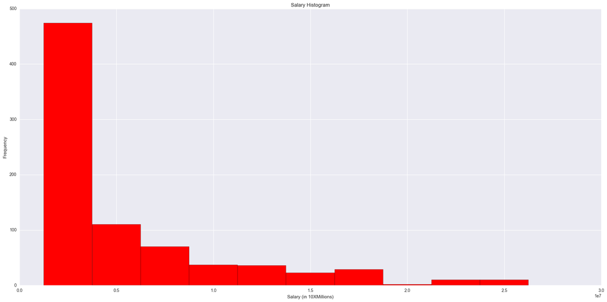

```python
#Plot a histogram with the salary from the master_2014_final dataframe
plt.figure(figsize=(20,10))
x = master_2014_final['salary']
bins = np.arange(0, master_2014_final['salary'].max(), 2500000)
#create the histogram
plt.title("Salary Histogram")
plt.xlabel("Salary (in 10XMillions)")
plt.ylabel("Frequency")
plt.tight_layout()
plt.hist(x, bins=bins,align='right',color='red',normed=0)
plt.show()
```

```python
#Count the no. of players with salary < USD2,500,000 and between 2,501,000 and 5,000,000

print len(master_2014_final[(master_2014_final['salary']<=2500000)])
print len(master_2014_final[(master_2014_final['salary']>2500000) & (master_2014_final['salary']<=5000000)])
```

```
478
121
```

# Conclusion:

The histogram shows a skewed distribution to the right, as shown above. A distribution skewed to the right is said to be positively skewed. This histogram depicts a large number of occurrences in the lower salary values (left side) and few in the upper salary values (right side).

478 out of 802 OR 60% of the players draw a salary less than USD 2,500,000. 121 players OR 15% draw a salary between USD2,500,000 and USD5,000,00. These two groups constitute 75% of the players.

# Single Variable Analysis 2:

Let us plot a bar diagram of no. of players based on their birth country. For this we will use the master_2014.csv file and create a dataframe using the count_the_items function. Let us call the dataframe as "players_by_country_df".

```python
#Call the count_the_items function to calculate the number of players by birth county from the master dataframe
#and create a new dataframe
players_by_country_df = count_the_items('master.csv','birthCountry','No. of Players')
players_by_country_df['No. of Players'].astype(int)
players_by_country_df.head()
```

|  | birthCountry | No. of Players |
| --- | --- | --- |
| 0 | Afghanistan | 1 |
| 1 | American Samoa | 1 |
| 2 | Aruba | 5 |
| 3 | At Sea | 1 |
| 4 | Australia | 28 |

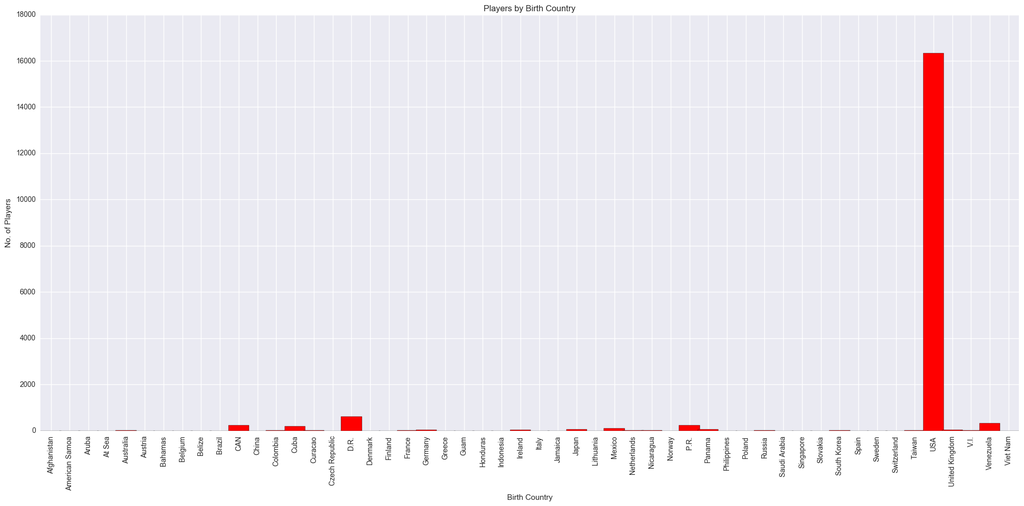

```python
#Plot a bar diagram with the no. of players based on birth country from the players_by_country_df dataframe
plt.figure(figsize=(20,10))
x = range(0,len(players_by_country_df))
y = players_by_country_df['No. of Players']
# create the bar diagram
plt.title("Players by Birth Country")
plt.xticks(x,players_by_country_df['birthCountry'] ,rotation='vertical')
plt.xlabel("Birth Country")
plt.ylabel("No. of Players")
plt.tight_layout()
plt.bar(x, y,color='red',align='center',width=1.1)
plt.show()
```

```python
#Print row count and top 5 countries by birth country
print len(master)
print players_by_country_df.sort_values('No. of Players', axis=0, ascending=False, inplace=False).head()
```

```
18589
   birthCountry  No. of Players
47          USA           16322
16         D.R.             619
50    Venezuela             321
34         P.R.             246
10          CAN             244
```

# Conculsion:

Overwhelmingly large number of players (16322 out of 18589) have USA as the birth country, followed by Dominican Republic (619) and Venezuela (321). This information does not lead to any relationship but by way of statistics.

# Multiple Variable Analysis:

Now let us analyze the relationship between the salary (dependent variable) and the characteristics of the players, like no. of awards won, years of play experience and the height of the player.

# Data cleaning and merging plan and Analysis:

1) Scatter plots will be created for Salary Vs. Awards Count, Salary Vs. Years of Experience and Salary Vs. Height. 2) This will be followed by calculation of the Pearson's Correlation Coefficient and the Inference and Significance will be discussed. 3) Finally, we will create a fitted model with the three independent variables , viz. award count and player's experience in completed years and Height. And the results will be analyzed.

master_2014_final dataframe will be mainly used for this part of analysis. pd.to_datetime and astype('timedelta64[Y]') will be used to cast the string and get the experience in years.

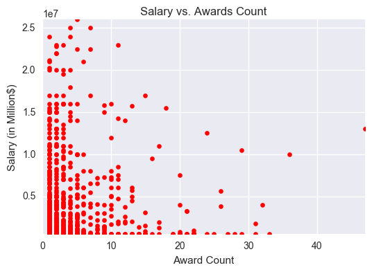

```python
#Plot the dependent variable and the independent variable as a scatter to find out the relationship
#The first plot is Salary (dependent variable) against No. of Awards Won (independent variable)
x = master_2014_final['awardID']
y = master_2014_final['salary']
plt.xlim(0, master_2014_final['awardID'].max())
plt.ylim(master_2014_final['salary'].min(), master_2014_final['salary'].max())
plt.scatter(x, y,color='red')
plt.title('Salary vs. Awards Count')
plt.xlabel('Award Count')
plt.ylabel('Salary (in Million$)')
plt.show()
```

# Inference

There doesn't seem to be any direct correlation between the number of Awards a player has won and his salary. Even players with no or few Awards are getting hight salaries.

```python
#Let us calculated the Pearson's Correlation Coefficient (r)
import scipy.stats
#c3 = scipy.stats.pearsonr(master_2014_final['salary'],master_2014_final['awardID'])
c3 = scipy.stats.pearsonr(master_2014_final['awardID'],master_2014_final['salary'])
print c3
```

```
(-0.020618519601142294, 0.55985320056078103)
```

# Significance of Pearson's correlation coefficient

In general, r > 0 indicates positive relationship, r < 0 indicates negative relationship while r = 0 indicates no relationship (or that the variables are independent and not related). As a rule of thumb, the following guidelines on strength of relationship are often useful (though there is scope for disagreement on the choice of boundaries). Value of r Strength of relationship -1.0 to -0.5 or 1.0 to 0.5 Strong -0.5 to -0.3 or 0.3 to 0.5 Moderate -0.3 to -0.1 or 0.1 to 0.3 Weak -0.1 to 0.1 None or very weak As rightly indicated by the scatter plot, there isn't any relationship between the salary and the awards won. Pearson correlation of Salary and Awards Won = -0.021 P-Value = 0.56 In conclusion, the above values indicate that the strength of association between the variables (Salary and No. of Awards) is none, even though r is a negative value, is very close to 0. Hence we can conclude there is no relationship between the two variables OR they are independent. The p-value significantly greater than 0.05.

```python
#Calculate the players' completed years of experience based on finalGame date and debut date
#and put the values a new column 'palyer_exp'
from datetime import datetime

master_2014_final['debut'] = pd.to_datetime(master_2014_final['debut'])
master_2014_final['finalGame'] = pd.to_datetime(master_2014_final['finalGame'])
master_2014_final['player_exp']= master_2014_final['finalGame'] -  master_2014_final['debut']
master_2014_final['player_exp'] = master_2014_final['player_exp'].astype('timedelta64[Y]')
#Drop rows with NaN values for 'player_exp'
master_2014_final = master_2014_final[master_2014_final['player_exp'] >= 0]
#Print top 5 rows to check data
print "Row count of Master_2014_final: "
print len(master_2014_final)
master_2014_final.head()
```

```
Row count of Master_2014_final:
797
```

|  | yearID | teamID | lgID | playerID | salary | birthYear | birthMonth | birthDay | birthCountry | birthState | ... | height | bats | throws | debut | finalGame | retroID | bbrefID | Unnamed: 0_y | awardID | player_exp |
| --- | --- | --- | --- | --- | --- | --- | --- | --- | --- | --- | --- | --- | --- | --- | --- | --- | --- | --- | --- | --- | --- |
| 0 | 2014 | ARI | NL | arroybr01 | 9500000 | 1977.0 | 2.0 | 24.0 | USA | FL | ... | 75.0 | R | R | 2000-06-12 | 2014-06-15 | arrob001 | arroybr01 | 32.0 | 1.0 | 14.0 |
| 1 | 2014 | ARI | NL | cahiltr01 | 7700000 | 1988.0 | 3.0 | 1.0 | USA | CA | ... | 76.0 | R | R | 2009-04-07 | 2014-09-26 | cahit001 | cahiltr01 | NaN | NaN | 5.0 |
| 2 | 2014 | ARI | NL | campato01 | 509500 | 1986.0 | 5.0 | 30.0 | USA | OH | ... | 68.0 | L | L | 2011-05-17 | 2014-09-28 | campt001 | campato01 | NaN | NaN | 3.0 |
| 3 | 2014 | ARI | NL | chaveer01 | 3500000 | 1977.0 | 12.0 | 7.0 | USA | CA | ... | 73.0 | L | R | 1998-09-08 | 2014-06-08 | chave001 | chaveer01 | 208.0 | 8.0 | 15.0 |
| 4 | 2014 | ARI | NL | collmjo01 | 925000 | 1986.0 | 2.0 | 7.0 | USA | MI | ... | 76.0 | R | R | 2011-04-17 | 2014-09-28 | collj001 | collmjo01 | NaN | NaN | 3.0 |

5 rows × 31 columns

```python
#Ascertain the range of salary
#master_2014_final = pd.read_csv('master_2014_final.csv')
print "The minimun salary is: "
print master_2014_final['salary'].min()
print "The maximu salary is: "
print master_2014_final['salary'].max()
```

```
The minimun salary is:
500000
The maximu salary is:
26000000
```

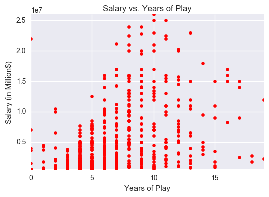

```python
#Plot the dependent variable and the independent variable as a scatter to find out the relationship
#The second plot is Salary (dependent variable) against No. of Completed Years[finalGame - debut] (independent variable)
x = master_2014_final['player_exp']
y = master_2014_final['salary']
plt.xlim(0, master_2014_final['player_exp'].max())
plt.ylim(master_2014_final['salary'].min(), master_2014_final['salary'].max())
plt.scatter(x, y,color='red')
plt.title('Salary vs. Years of Play')
plt.xlabel('Years of Play')
plt.ylabel('Salary (in Million$)')
plt.show()
```

```python
#Let us calculated the Pearson's Correlation Coefficient (r)
import scipy
c4 = scipy.stats.pearsonr(master_2014_final['salary'],master_2014_final['player_exp'])
print c4
```

```
(0.55848960071538767, 1.4697288980057592e-66)
```

# Significance of Pearson's correlation coefficient

The value of r is: 0.56 and p-value is 0.000 Value of r Strength of relationship -1.0 to -0.5 or 1.0 to 0.5 Strong

The scatter plot indicates that there is strong relationship between the salary and the years of experience.

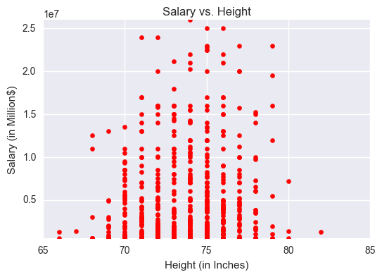

```python
#Plot the dependent variable and the independent variable as a scatter to find out the relationship
#The third plot is Salary (dependent variable) against height of the player (independent variable)
x = master_2014_final['height']
y = master_2014_final['salary']

plt.ylim(master_2014_final['salary'].min(), master_2014_final['salary'].max())
plt.scatter(x, y,color='red')
plt.title('Salary vs. Height')
plt.xlabel('Height (in Inches)')
plt.ylabel('Salary (in Million$)')
plt.show()
```

```python
#Let us calculated the Pearson's Correlation Coefficient (r)
import scipy
c5 = scipy.stats.pearsonr(master_2014_final['salary'],master_2014_final['height'])
print c5
```

```
(0.10857787982780445, 0.0021438102255504111)
```

# Significance of Pearson's correlation coefficient

As indicated by the scatter plot, there is weak relationship between the salary and the height. Pearson correlation of Salary and Height = 0.11 P-Value = 0.002

Value of r Strength of relationship -1.0 to -0.5 or 1.0 to 0.5 Strong -0.5 to -0.3 or 0.3 to 0.5 Moderate -0.3 to -0.1 or 0.1 to 0.3 Weak -0.1 to 0.1 None or very weak

In conclusion, the above values indicate that a weak positive relationship between the variables (Salary and of the Player) , the r value falling between 0.1 and 0.3. The p-value is less than 0.05.

# Limitations of Pearson's Correlation Coefficient:

While 'r' (correlation coefficient) is a powerful tool, it has to be handled with care. Here are the limitations:

1) The most used correlation coefficients only measure linear relationship. It is therefore perfectly possible that while there is strong non linear relationship between the variables, r is close to 0 or even 0. In such a case, a scatter diagram can roughly indicate the existence or otherwise of a non linear relationship.

2) One has to be careful in interpreting the value of 'r'. For example, one could compute 'r' between the size of shoe and intelligence of individuals, heights and income. Irrespective of the value of 'r', it makes no sense and is hence termed chance correlation.

3) 'r' should not be used to say anything about cause and effect relationship. Put differently, by examining the value of 'r', we could conclude that variables X and Y are related. However the same value of 'r' does not tell us if X influences Y or the other way round. Statistical correlation should not be the primary tool used to study causation, because of the problem with third variables.

# Creation of fitted model and Analysis:

Statsmodel is a Python library designed for more statistically-oriented approaches to data analysis, with an emphasis on econometric analyses. It integrates well with the pandas and numpy libraries we covered in a previous post. It also has built in support for many of the statistical tests to check the quality of the fit and a dedicated set of plotting functions to visualize and diagnose the fit.

We will make use of the smf.ols Statsmodels provides a formulaic interface that is similart to that of R. The class is now called ols rather than OLS. ols stands for Ordinary Least Squares. The argument formula allows you to specify the response and the predictors using the column names of the input data frame data. The summary function provides quite a lot of information about the fit. Among other values in the summary, the following are the most important:

R-squared The coefficient of determination. A statistical measure of how well the regression line approximates the real data points Adj. R-squared The above value adjusted based on the number of observations and the degrees-of-freedom of the residuals t The t-statistic value. This is a measure of how statistically significant the coefficient is. P > |t| P-value that the null-hypothesis that the coefficient = 0 is true. If it is less than the confidence level, often 0.05, it indicates that there is a statistically significant relationship between the term and the response. [95.0% Conf. Interval] The lower and upper values of the 95% confidence interval

```python
# create a fitted model with the three independent variables , viz. award count and
#player's experience in completed years and Height.
import statsmodels.formula.api as smf
lm = smf.ols(formula='salary ~ player_exp + height + awardID', data=master_2014_final).fit()
# print a summary of the fitted model
lm.summary()
```

OLS Regression Results

| Dep. Variable: | salary | R-squared: | 0.320 |
| --- | --- | --- | --- |
| Model: | OLS | Adj. R-squared: | 0.318 |
| Method: | Least Squares | F-statistic: | 124.5 |
| Date: | Tue, 11 Oct 2016 | Prob (F-statistic): | 4.42e-66 |
| Time: | 22:26:52 | Log-Likelihood: | -13296. |
| No. Observations: | 797 | AIC: | 2.660e+04 |
| Df Residuals: | 793 | BIC: | 2.662e+04 |
| Df Model: | 3 |  |  |
| Covariance Type: | nonrobust |  |  |

|  | coef | std err | t | P>\|t\| | [95.0% Conf. Int.] |
| --- | --- | --- | --- | --- | --- |
| Intercept | -1.448e+07 | 4.68e+06 | -3.092 | 0.002 | -2.37e+07 -5.29e+06 |
| player_exp | 7.569e+05 | 3.99e+04 | 18.961 | 0.000 | 6.79e+05 8.35e+05 |
| height | 1.954e+05 | 6.35e+04 | 3.076 | 0.002 | 7.07e+04 3.2e+05 |
| awardID | -1.004e+04 | 2.73e+04 | -0.368 | 0.713 | -6.35e+04 4.35e+04 |

| Omnibus: | 246.864 | Durbin-Watson: | 1.942 |
| --- | --- | --- | --- |
| Prob(Omnibus): | 0.000 | Jarque-Bera (JB): | 837.295 |
| Skew: | 1.470 | Prob(JB): | 1.53e-182 |
| Kurtosis: | 7.070 | Cond. No. | 2.30e+03 |